# Lab 3

Team 5

9/23/2020

## 1. Find the average years of education for the respondents with each political party affiliation. Arrange your output in a meaningful order. Describe any pattern you find.

**Observation**` As the political party affiliation moves more to the right the average education level slightly increases.

```r
dat = dat %>% drop_na()
dat <- dat %>%
  mutate(School = as.numeric(School))

dat %>%
  group_by(PolParty) %>%
  summarize(AvgEdu = mean(School, na.rm = TRUE), MedEdu = median(School, na.rm = TRUE)) %>%
  arrange(AvgEdu)
```

```
## # A tibble: 10 x 3
##    PolParty           AvgEdu MedEdu
##    <chr>               <dbl>  <dbl>
##  1 Don't know           10.9     11
##  2 No answer            12.3     12
##  3 Independent          12.3     12
##  4 Strong democrat      12.5     12
##  5 Not str democrat     12.6     12
##  6 Ind,near dem         13.2     13
##  7 Not str republican   13.3     13
##  8 Ind,near rep         13.3     13
##  9 Other party          13.4     13
## 10 Strong republican    13.4     13
```

```r
order <- c("Strong democrat", "Not str democrat", "Ind,near dem", "Independent", "Other party", "Ind,near rep", "Not str republican", "Strong republican")

dat2 <- dat %>% select(PolParty, School) %>% drop_na %>%
  mutate(School = as.numeric(School, na.rm = TRUE)) %>%
  group_by(PolParty) %>%
  summarize(meanYears = mean(School, na.rm = TRUE)) %>%
  filter(PolParty != "Don't know" & PolParty != "No answer") %>%
  mutate(PolParty = factor(PolParty, levels = order)) %>%
  arrange(PolParty)
```

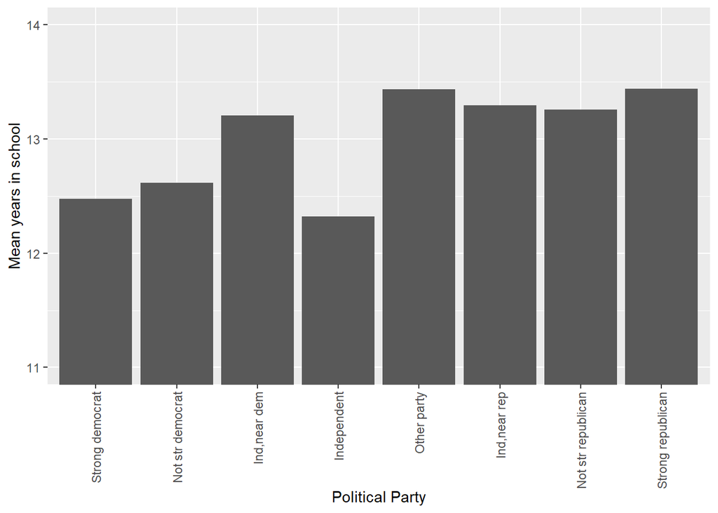

```r
ggplot(dat2, aes(x = PolParty, weight = meanYears)) +
  geom_bar() +
  theme(axis.text.x = element_text(angle = 90, vjust = .5, hjust = 1)) +
  labs(x = "Political Party", y = "Mean years in school") +
  coord_cartesian(ylim = c(11, 14))
```

This is a bar plot that shows the average year in school with the political parties mentioned in the data. Note that the “Don’t know” and “Other Answer” categories were omitted by nature of them not being political parties. The scale goes from 11 years to 14 years to manipulate the scale to better see the differences (as differences between the parties are too minimal to meaningfully see at such scales). The grouping of the political parties was done based on an approximation of the “political compass” wherein Strong Democrats are furthest to the left and Strong Republicans are furthest to the right. The only problem here is that the “Other Party” is unclear as to political leaning on the “compass” so it was placed in the middle to be as neutral as possible.

The republican leaning parties tend to be more educated on average when compared to the democratic leaning party answers.

## 2. Create a single data frame containing records for the better educated respondents in each political party affiliation. A “better educated” respondent is someone who has more years of education than the median within the same party affiliation. Print the structure of the data frame.

```r
PolPartyEdu <- dat %>%
  select(PolParty, School)

PolPartyEdu <- PolPartyEdu %>%
  group_by(PolParty) %>%
  filter(School >= median(School, na.rm = TRUE))

str(PolPartyEdu)
```

```
## tibble [40,925 x 2] (S3: grouped_df/tbl_df/tbl/data.frame)
##  $ PolParty: chr [1:40925] "Ind,near dem" "Independent" "Not str democrat" "Strong democrat" ...
##  $ School  : num [1:40925] 16 12 17 12 14 13 16 12 12 13 ...
##  - attr(*, "groups")= tibble [10 x 2] (S3: tbl_df/tbl/data.frame)
##   ..$ PolParty: chr [1:10] "Don't know" "Ind,near dem" "Ind,near rep" "Independent" ...
##   ..$ .rows   : list<int> [1:10]
##   .. ..$ : int [1:7] 1471 1479 1881 1972 2045 2201 35313
##   .. ..$ : int [1:3949] 1 5 6 7 13 15 26 34 43 53 ...
##   .. ..$ : int [1:2944] 12 14 19 37 68 84 87 89 90 105 ...
##   .. ..$ : int [1:7141] 2 17 18 24 27 31 36 39 45 71 ...
##   .. ..$ : int [1:271] 546 934 942 994 1220 1576 1599 1752 1868 1915 ...
##   .. ..$ : int [1:9935] 3 21 25 33 41 44 49 54 56 58 ...
##   .. ..$ : int [1:5188] 22 23 32 35 40 48 51 66 83 95 ...
##   .. ..$ : int [1:605] 38 42 47 96 149 169 201 215 276 284 ...
##   .. ..$ : int [1:7306] 4 8 9 10 11 20 28 29 30 46 ...
##   .. ..$ : int [1:3579] 16 50 52 80 82 101 103 148 163 171 ...
##   .. ..@ ptype: int(0)
##   ..- attr(*, ".drop")= logi TRUE
```

## 3. How is the happiness of a respondent related to his/her marriage status?

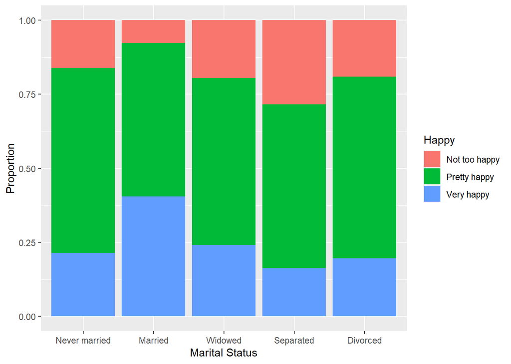

```r
order <- c("Never married", "Married", "Widowed", "Separated", "Divorced")
dat2 <- dat %>% select(Happy, Married) %>% drop_na %>%
  filter(Married != "No answer" & Happy != "Not applicable" & Happy != "No answer" & Happy != "Don't know") %>%
  mutate(Married = factor(Married, levels = order)) %>%
  arrange(Married)
ggplot(dat2, aes(x = Married, fill = Happy)) + geom_bar(position = 'fill') +
  labs(x = "Marital Status", y = "Proportion")
```

Married people have the highest proportion of “Very happy” people by a wide margin and the least “Not too happy” people by a similarly large margin. Meanwhile, the separated category has the most “Not too happy” people and least “Very happy” people, while the other three not married categories are roughly the same. This indicates that marriage positively correlates to general happiness. A final note is that the “Pretty Happy” is noticeably similar in proportion across all marital statuses.

## 4. Does party affiliation affect the relationship you found in the last question?

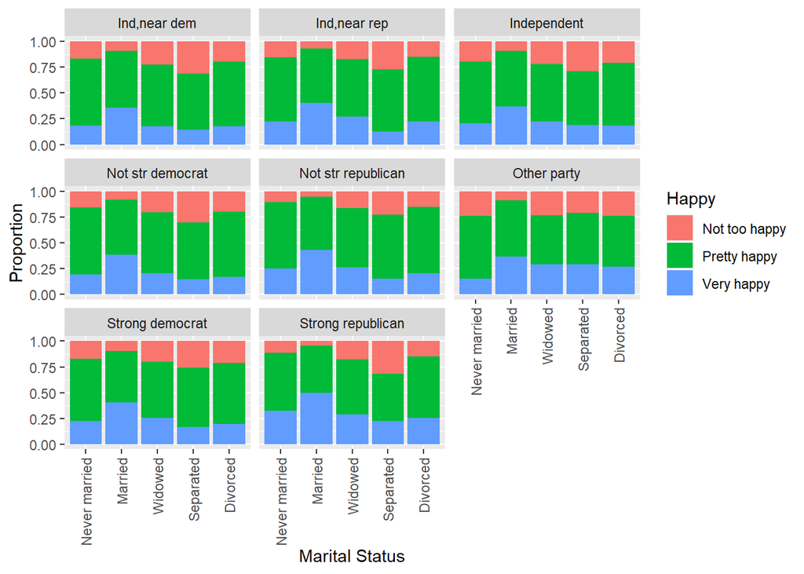

```r
order <- c("Never married", "Married", "Widowed", "Separated", "Divorced")
dat2 <- dat %>% select(Happy, Married, PolParty) %>% drop_na %>%
  filter(Married != "No answer" & Happy != "Not applicable" & Happy != "No answer" & Happy != "Don't know" & PolParty != "Don't know" & PolParty != "No answer") %>%
  mutate(Married = factor(Married, levels = order)) %>%
  arrange(Married)
ggplot(dat2, aes(x = Married, fill = Happy)) + geom_bar(position = 'fill') +
  labs(x = "Marital Status", y = "Proportion") + facet_wrap(~PolParty) +
  theme(axis.text.x = element_text(angle = 90, vjust = .5, hjust = 1))
```

Political party does not seem to have a major effect on the relationship. The same general shape of the graph can be seen in each of the party affiliations.

## 5. How is marital status related to the education of a respondent? What are possible reasons accounting for the patterns you see?

```r
order <- c("Never married", "Married", "Widowed", "Separated", "Divorced")

dat3 <- dat %>% select(Married, School) %>% drop_na %>%
  mutate(School = as.numeric(School, na.rm = TRUE)) %>%
  group_by(Married) %>%
  filter(Married != "Don't know" & Married != "Not applicable") %>%
  summarize(meanYears = mean(School, na.rm = TRUE)) %>%
  mutate(Married = factor(Married, levels = order)) %>%
  drop_na %>%
  arrange(Married)
```

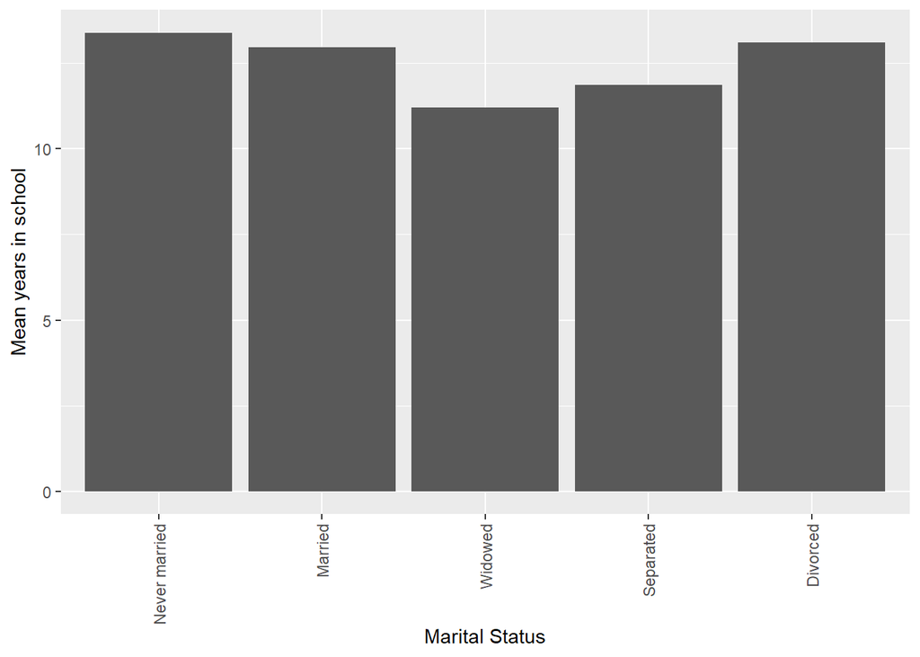

```r
ggplot(dat3, aes(x = Married, weight = meanYears)) +
  geom_bar() +
  theme(axis.text.x = element_text(angle = 90, vjust = .5, hjust = 1)) +
  labs(x = "Marital Status", y = "Mean years in school") +
  coord_cartesian()
```

The “Never married” bar has the most average years in school. A likely reason for this may be that people spending many years in school may focus more on their education than dating, resulting in not getting married. The “Widowed” bar has the lowest average education time. This may have to do with people getting married earlier in life then not having time for higher education.

## 6. Explore two more interesting questions, and answer those questions using the GSS data.

*How many vocabulary words did the respondent get correct based on their education level?* For the most part as the education level increases so does their vocabulary.

```r
dat <- dat %>%
  mutate(Vocab = as.numeric(Vocab))
```

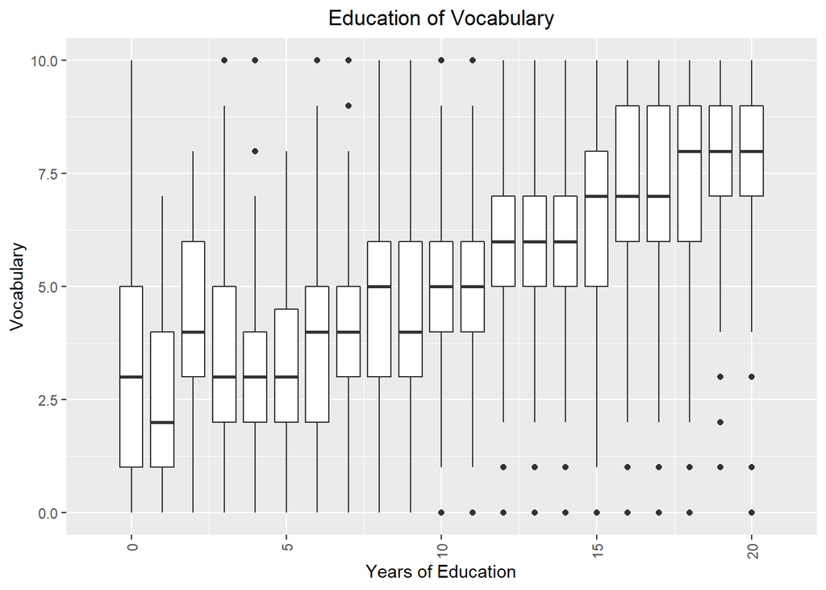

```r
##str(dat)

YearEd <- c(0, 1, 2, 3, 4, 5, 6, 7, 8, 9, 10, 11, 12, 13, 14, 15, 16, 17, 18, 19, 20, "Don't know", "No answer")

ggplot(aes(x=School, y=Vocab, group=School), data=dat) + geom_boxplot() + ggtitle("Education of Vocabulary") + theme(plot.title = element_text(hjust = 0.5), axis.text.x = element_text(angle = 90, vjust = 0.5, hjust=1)) + ylab("Vocabulary") + xlab("Years of Education") + scale_x_discrete(limits = YearEd) + scale_x_continuous(limits = c(-1,21))
```

*How does Astrological Sign influence the number of years a person might be in school?*

```r
dat2 <- dat %>% select(Sign, School) %>% drop_na %>%
  mutate(School = as.numeric(School, na.rm = TRUE)) %>%
  group_by(Sign) %>%
  summarize(meanYears = mean(School, na.rm = TRUE)) %>%
  filter(Sign != "Don't know" & Sign != "No answer" & Sign != "Not applicable")
```

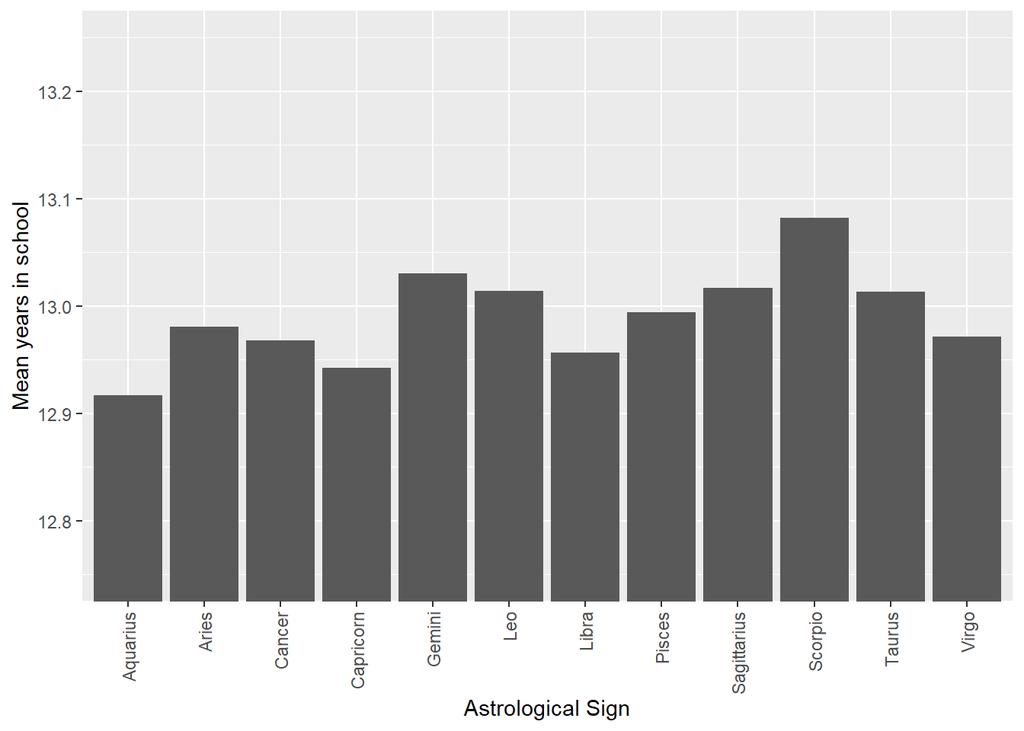

```r
ggplot(dat2, aes(x = Sign, weight = meanYears)) +
  geom_bar() +
  theme(axis.text.x = element_text(angle = 90, vjust = .5, hjust = 1)) +
  labs(x = "Astrological Sign", y = "Mean years in school") +
  coord_cartesian(ylim = c(12.75, 13.25))
```

Many people care about astrological sign and relative time of birth may have some correlation with academic pursuits. This bar chart shows that there can be some minor differences in the mean years in school. Interestingly, there is nearly a .2 difference in the mean between the Scorpio and Aquarius categories. Considering the large size of the data set, this could be worth further investigation to see if the time of birth could influence aspects of a person’s life such as academic pursuit.